# 统计计算第二次作业报告

林子开

2023-10-08

# Exercise 5.2

Monte Carlo estimate of the standard normal cdf, compared with the **pnorm** function is as follows:

```r
set.seed(123)
xx = seq(-2,2,length=21)
cdfs = numeric(length(xx))
for(i in 1:length(xx)){
  x = xx[i]
  if(x>=0){
    m = 1e4
    u = runif(m,0,x)
    cdf = 0.5 + x*mean(exp(-u^2/2))/sqrt(2*pi)}
  else{
    x = -x
    m = 1e4
    u = runif(m,0,x)
    cdf = 0.5 - x*mean(exp(-u^2/2))/sqrt(2*pi)
  }
  cdfs[i] = cdf
}
Phi = pnorm(xx)
print(round(rbind(xx,cdfs,Phi),4))
```

```
##         [,1]    [,2]    [,3]    [,4]    [,5]    [,6]    [,7]    [,8]    [,9]
## xx   -2.0000 -1.8000 -1.6000 -1.4000 -1.2000 -1.0000 -0.8000 -0.6000 -0.4000
## cdfs  0.0208  0.0334  0.0553  0.0778  0.1150  0.1591  0.2117  0.2742  0.3446
## Phi   0.0228  0.0359  0.0548  0.0808  0.1151  0.1587  0.2119  0.2743  0.3446
##        [,10] [,11]  [,12]  [,13]  [,14]  [,15]  [,16]  [,17]  [,18]  [,19]
## xx   -0.2000   0.0 0.2000 0.4000 0.6000 0.8000 1.0000 1.2000 1.4000 1.6000
## cdfs  0.4207   0.5 0.5793 0.6554 0.7258 0.7879 0.8411 0.8849 0.9182 0.9458
## Phi   0.4207   0.5 0.5793 0.6554 0.7257 0.7881 0.8413 0.8849 0.9192 0.9452
##       [,20]  [,21]
## xx   1.8000 2.0000
## cdfs 0.9655 0.9811
## Phi  0.9641 0.9772
```

The estimate of the variance of my MC estimate of Phi(2) and a 95% CI for Phi(2) is as follows:

```r
set.seed(123)
m = 1e4
u = runif(m,0,2)
g = 0.5 + x*exp(-u^2/2)/sqrt(2*pi)
cdf = mean(g)
v = mean((g-cdf)^2)/m
se = sqrt(v)
CI = c(cdf-1.96*se,cdf+1.96*se)
print(v)
```

```
## [1] 5.232255e-06
```

```r
print(CI)
```

```
## [1] 0.9746962 0.9836628
```

# Exercise 5.3

The first method with the corresponding variance is as follows:

```r
set.seed(555)
INT1 = function(m){
  u = runif(m,0,0.5)
  g = exp(-u)
  theta.hat = 0.5*mean(g)
  return(theta.hat)
}
m = 1e4
theta.hat = numeric(1e3)
for(i in 1:1e3){
  theta.hat[i] = INT1(m)
}
v.hat = var(theta.hat)
print(v.hat)
```

```
## [1] 3.203621e-07
```

The second method with the corresponding variance is as follows:

```r
set.seed(555)
INT2 = function(m){
  u = rexp(m)
  g = u<=0.5
  theta.star = mean(g)
  return(theta.star)
}
m = 1e4
theta.star = numeric(1e3)
for(i in 1:1e3){
  theta.star[i] = INT2(m)
}
v.star = var(theta.star)
print(v.star)
```

```
## [1] 2.334702e-05
```

And the empirical percent reduction is:

```r
(v.star-v.hat)/v.star
```

```
## [1] 0.9862782
```

The variance of $\hat{\theta}$ is smaller than $\theta^*$. Here I give a theoretical proof. We have
$$\hat{\theta} =
\frac{1}{2}\frac{1}{m}\Sigma_{i=1}^m\text{e}^{u_i}$$
And the variance of $\hat{\theta}$ is:
$$\begin{align}
Var(\hat{\theta}) &= \frac{1}{4m}{Var(e^U)}
\end{align}$$
where $U$ from Uniform(0,0.5), and
$$\begin{align}
Var(e^U) &= \int_0^{0.5}2e^{-2x}\,\text{d}x - \left[
\int_0^{0.5}2e^{-x}\,\text{d}x\right]^2\\
&= 0.012848
\end{align}$$

On the other hand,
$$\begin{align}
Var(\theta^*)& = \frac{\theta(1-\theta)}{m} \\
&= \frac{e^{-1/2}(1-e^{-1/2})}{m}\\
&= \frac{0.238651218541}{m}
\end{align}$$
Then the theoretical percent variance is
$$\begin{align}
\frac{Var(\theta^*)-Var(\hat{\theta})}{Var(\theta^*)}&=\frac{0.238651218541-
0.012848/4}{0.238651218541}\\
&=0.9865
\end{align}$$
which is consistent with the experimental result above.

# Exercise 5.6

Assume $\theta_1$ the estimate by antithetic variates, and $\theta_2$ is obtained by simple MC.
$$\theta_1 =
\frac{1}{m}\Sigma_{i=1}^{m/2}(e^{u_i}+e^{1-u_i})$$
$$\begin{align}
Var(\theta_1) &=
\frac{1}{m^2}\Sigma_{i=1}^{m/2}(Var(e^{u_i}+e^{1-u_i}))\\
&= \frac{1}{2m}[Var(e^U)+Var(e^{1-U})+2Cov(e^U,e^{1-U})]
\end{align}$$

where

$$\begin{align}
Var(e^U)&=Var(e^{1-U}) =
E[e^{2U}]-(E[e^U])^2=\frac{1}{2}(e^2-1)-(e-1)^2=0.24203\\
Cov(e^U,e^{1-U}) &= E[e^U e^{1-U}] - E[e^U]E[e^{1-U}]= e − (e − 1)^2
= −0.23421
\end{align}$$

On the other hand,
$$Var(\theta_2) =
\frac{1}{m}Var(e^U)$$
Then the percent reduction in variance is:
$$\begin{align}
&\quad \frac{Var(\theta_2)-Var(\theta_1)}{Var(\theta_2)} \\
&=\frac{0.24203-(0.24203-0.23421)}{0.24203}\\
&=0.9677
\end{align}$$

# Exercise 5.7

Antithetic variate approach and the simple MC method to estimate $\theta$ with their variance are as follows:

```r
MC.simple = function(x,R=1e4){
  u = runif(R,0,x)
  INTEG = x*mean(exp(u))
}
MC.ant = function(x,R=1e4){
  u = runif(R/2,0,x)
  v = 1-u
  u = c(u,v)
  INTEG = x*mean(exp(u))
}
set.seed(123)
m = 1000
MC1 <- MC2 <- numeric(m)
for(i in 1:1000){
  MC1[i] = MC.simple(1)
  MC2[i] = MC.ant(1)
}
v.simple = var(MC1)
v.ant = var(MC2)
```

And the empirical estimate of the percent reduction in variance using the antithetic variate is:

```r
(v.simple-v.ant)/v.simple
```

```
## [1] 0.9693727
```

which is very close to the theoretical value 0.9677 from Exercise 5.6

# Exercise 5.8

Since Uniform distribution is a special case of symmetric Beta distribution, we can directly prove the claim for symmetric beta distribution.

Because of symmetricity,
$$E[U]=1/2, \,
E[1-U]=1/2$$
Suppose
$$Var(U)=Var(1-U)=\sigma^2$$
and then we have
$$E[U^2]=Var(U)+(E[U])^2 = \sigma^2 +
1/4$$
and
$$E[X]=E[X']=a/2,\quad
Var(X)=Var(X')=a^2\sigma^2,\quad
E[X^2]=E[X'^2]=a^2\sigma^2 + a^2/4$$

Therefore,
$$\begin{align}
Cov(X,X') &= a^2(\,E[U(1-U)]-E[U]E[1-U]\,)\\
&=a^2(E[U] - E[U^2] - E[U]E[1-U])\\
&=a^2(1/2 - (\sigma^2 + 1/4) -(1/2)^2 )\\
&= -a^2\sigma^2
\end{align}$$

Then the correlation is:
$$\begin{align}
\rho(X,X')&=\frac{Cov(X,X')}{\sqrt{Var(X)Var(X')}}\\
&=\frac{-a^2\sigma^2}{a^2\sigma^2}\\
&=-1
\end{align}$$

# Exercise 5.10

```r
set.seed(123)
MC.simple = function(x,R=1e4){
  u = runif(R,0,x)
  INTEG = x*mean(exp(-u)/(1+u^2))
}
MC.ant = function(x,R=1e4){
  u = runif(R/2,0,x)
  v = 1-u
  u = c(u,v)
  INTEG = x*mean(exp(-u)/(1+u^2))
}
set.seed(123)
m = 1000
MC1 <- MC2 <- numeric(m)
for(i in 1:1000){
  MC1[i] = MC.simple(1)
  MC2[i] = MC.ant(1)
}
v.simple = var(MC1)
v.ant = var(MC2)
(v.simple-v.ant)/v.simple
```

```
## [1] 0.966296
```

# Approximate the fraction of a hypersphere in hypercube

## The formula for the EXACT values of the fraction

According to WIKIPEDIA https://en.wikipedia.org/wiki/Volume_of_an_n-ball, the volumn of an d-dimension hypersphere is
$$V_{sphere}(d,R)=\frac{\pi^{d/2}}{\Gamma(\frac{d}{2}+1)}R^d$$
and the volumn of the inscribed d-dimensional hypercube is
$$V_{cube}(d,R)=(2R)^d$$
Therefore the the fraction of a d-dimensional hypersphere which lies in the inscribed d-dimensional hypercube is
$$f(d) =
\frac{V_{sphere}(d,R)}{V_{cube}(d,R)}=\frac{\pi^{d/2}}{2^d\Gamma(\frac{d}{2}+1)}$$
where the Gamma function is
$$\Gamma(\frac{d}{2}+1) = \begin{cases}
(\frac{1}{2})! \quad & \text{if } d \text{ is even} \\
\pi^{\frac{1}{2}} \Pi_{j=0}^{d-1}(\frac{1}{2}+j) &
\text{otherwise.}
\end{cases}$$

## Approximate the value of $\pi$ by Monte Carlo

```r
set.seed(123)
# Define the function to calculate pi using Monte Carlo simulation
MC_pi <- function(d) {
  r <- 0.5
  x = matrix(runif(d, -r, r),ncol=d)
  pi_estimate <- 0
  n = 0
  in_sphere = 0
  while (TRUE) {
    n = n + 1
    x = runif(d, -r, r) # d维空间中的一个点
    in_sphere = in_sphere + as.numeric(sum(x^2) <= r^2) # 判断该点是否在球内
    fraction = in_sphere/n
    pi_estimate = (fraction*2^d*gamma(d/2+1))^(2/d)
    # print(pi_estimate)
    if ((pi_estimate*1e5)%/%1 == 314159)  break
  }
  return(n)
}

dimensions = 2:10
ns = numeric(length(dimensions))
for(i in 1:length(dimensions)){
  ns[i] = MC_pi(dimensions[i])
}
print(rbind(dimensions,ns))
```

```
##            [,1]  [,2]  [,3] [,4] [,5]    [,6]  [,7] [,8]     [,9]
## dimensions    2     3     4    5    6       7     8    9       10
## ns         9753 19746 10077  997 6440 6715578 15390 4191 16820432
```

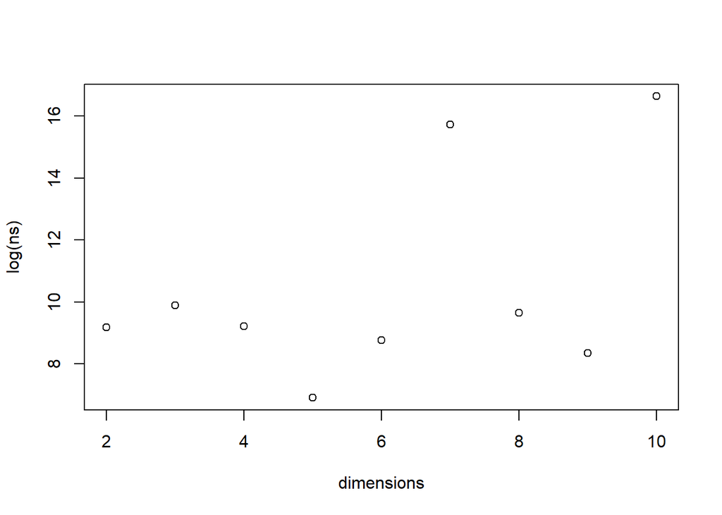

```r
plot(dimensions,log(ns))
```

```r
#            [,1]  [,2]  [,3] [,4] [,5]    [,6]  [,7] [,8]     [,9]
# dimensions    2     3     4    5    6       7     8    9       10
# ns         9753 19746 10077  997 6440 6715578 15390 4191 16820432
```